# Exploring the EEG signals of Schizophrenia

### Hollie Keating, Sarah Conway, Maeve Samali<sup>1</sup>

##### <sup>1</sup> School of Mathematical and Statistical Sciences, University of Galway

# Background

The brain typically suppresses its response to expected stimuli (sensory gating).

Schizophrenia is associated with impaired sensory gating[^1].

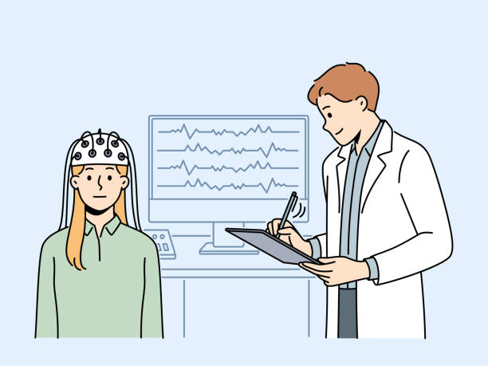

Figure 1: EEG illustration[^2]

### Data

Our data were taken from the National Institute of Mental Health (NIMH project number R01MH058262), available from Kaggle

In our data, 36 subjects were exposed to three conditions (25 controls, 11 cases):

1. Subjects press a button to immediately produce a sound
2. Subjects passively listen to the same sound without pressing a button
3. Subjects press a button, and no sound is produced.

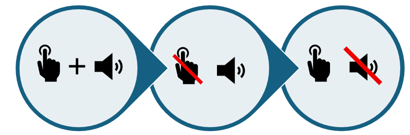

Figure 2: Condition Visualisation

### Objectives of Project

- *Hypothesis:* Individuals with schizophrenia exhibit statistically different EEG signals compared to healthy controls during conditions ~100ms.
- *How?:* Functional Data Analysis (FDA) was applied to investigate the difference in EEG signals in the FP1 node.
- *Why FP1?:* Previous EEG studies reported altered frontal activity and reduced frontal coherence in relation to schizophrenia research. [^3]

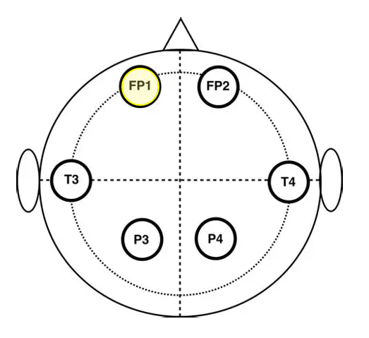

Figure 3: Nodes Cap[^4]

# Results

### Raw Data

[figure not shown]

Figure 4: Raw Data Plot, Condition 1: Cases vs Controls

### Smoothing Process

Spline smoothing was applied to remove noise from data:

- 100 cubic B-spline functions between [0, 1638]ms
- Second derivative penalty applied

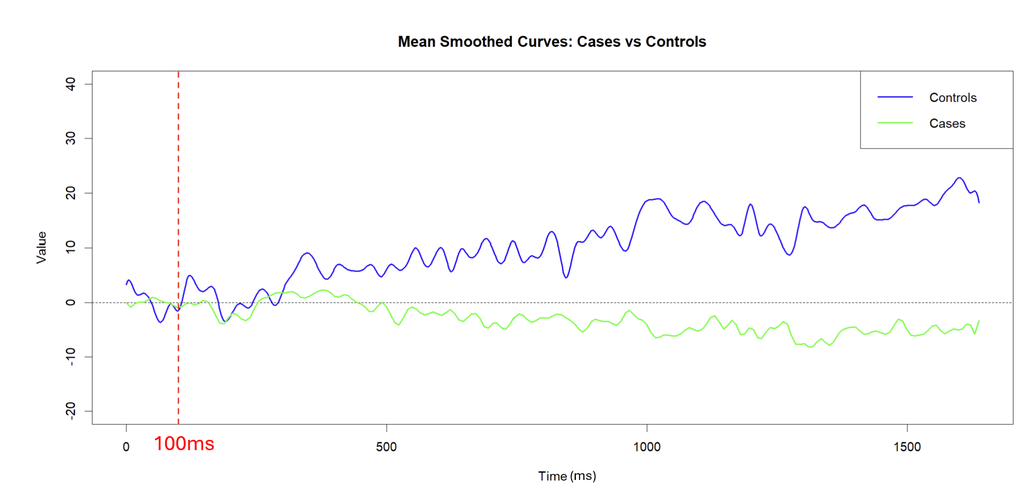

Figure 5: Mean Smoothed Curves Plot, Condition 1: Cases vs Controls